# Wrangle & Analyze Data

## (WeRateDogs Twitter Archive Project)

### By: Kariman Fawzi

## Contents¶

- Introduction
- Data Gathering
- Data Assessing
- Data Cleaning
- Data Storing
- Data Analysis and Data Visualization
- Conclusions

### Introduction

This Jupyter Notebook aims to document the process of Gathering, Assessing, and Cleaning of WeRateDogs Twitter Archive dataset.

#### Importing Libaries

For this project I will use some libraries to manage data frames, download file, Twitter API Client code, etc.. So, let's import this packages to the Jupyter Notebook environment.

```python
# Importing Library.

# Importing pandas to work with DataFrames.
import pandas as pd

# Importing numpy to general methods.
import numpy as np

# Importing OS package to write and open files.
import os

# Importing the requests to create a object from a given URL.
import requests

# Importing the Client Code to use the Twitter API.
import tweepy

# Importing the json package to easy my task with json files
import json

# Importing the time package to calculate the elapse time to access the Twitter API
import time

# Importing the re package to use the regular expressions.
import re

# Importing the matplotlib to create graphics
import matplotlib.pyplot as plt
%matplotlib inline

# Import seaborn for better visualization
import seaborn as sns
```

### Data Gathering

A- There are two (2) files hosted in Udacity website that I must have to gather (download).

1- (twitter-archive-enhanced.csv)

This file will be treated as a file on hand, I will manually download it and read it into the noetbook.

2- (image-predictions.tsv)

This file (image_predictions.tsv) is hosted on Udacity's servers and should be downloaded programmatically using the Requests library and the given URL to it.

B- Later, I will access the Twitter API to gather additional data.

```python
# load csv file into df (loading the twitter_archive_enhanced csv file)
df_arch = pd.read_csv('twitter-archive-enhanced.csv')

#check the file loading into a dataframe
df_arch.head()
```

|  | tweet_id | in_reply_to_status_id | in_reply_to_user_id | timestamp | source | text | retweeted_status_id | retweeted_status_user_id | retweeted_status_timestamp | expanded_urls | rating_numerator | rating_denominator | name | doggo | floofer | pupper | puppo |
| --- | --- | --- | --- | --- | --- | --- | --- | --- | --- | --- | --- | --- | --- | --- | --- | --- | --- |
| 0 | 892420643555336193 | NaN | NaN | 2017-08-01 16:23:56 +0000 | <a href="http://twitter.com/download/iphone" r... | This is Phineas. He's a mystical boy. Only eve... | NaN | NaN | NaN | https://twitter.com/dog_rates/status/892420643... | 13 | 10 | Phineas | None | None | None | None |
| 1 | 892177421306343426 | NaN | NaN | 2017-08-01 00:17:27 +0000 | <a href="http://twitter.com/download/iphone" r... | This is Tilly. She's just checking pup on you.... | NaN | NaN | NaN | https://twitter.com/dog_rates/status/892177421... | 13 | 10 | Tilly | None | None | None | None |
| 2 | 891815181378084864 | NaN | NaN | 2017-07-31 00:18:03 +0000 | <a href="http://twitter.com/download/iphone" r... | This is Archie. He is a rare Norwegian Pouncin... | NaN | NaN | NaN | https://twitter.com/dog_rates/status/891815181... | 12 | 10 | Archie | None | None | None | None |
| 3 | 891689557279858688 | NaN | NaN | 2017-07-30 15:58:51 +0000 | <a href="http://twitter.com/download/iphone" r... | This is Darla. She commenced a snooze mid meal... | NaN | NaN | NaN | https://twitter.com/dog_rates/status/891689557... | 13 | 10 | Darla | None | None | None | None |
| 4 | 891327558926688256 | NaN | NaN | 2017-07-29 16:00:24 +0000 | <a href="http://twitter.com/download/iphone" r... | This is Franklin. He would like you to stop ca... | NaN | NaN | NaN | https://twitter.com/dog_rates/status/891327558... | 12 | 10 | Franklin | None | None | None | None |

```python
#Using the requests package to download image predictions data from Udacity Server
url = 'https://d17h27t6h515a5.cloudfront.net/topher/2017/August/599fd2ad_image-predictions/image-predictions.tsv'
response = requests.get(url)
response
```

```
<Response [200]>
```

```python
#HTTP status code 200 indicates the request has succeeded
#creating image file to transform into a dataframe later

file_images = url.split('/')[-1]

with open(os.path.join('./', file_images), mode = 'wb') as file:
    file.write(response.content)
```

```python
# read image predictions file into a DataFrame

df_imgpredict = pd.read_csv(file_images, sep = '\t', engine = 'python')
df_imgpredict
```

|  | tweet_id | jpg_url | img_num | p1 | p1_conf | p1_dog | p2 | p2_conf | p2_dog | p3 | p3_conf | p3_dog |
| --- | --- | --- | --- | --- | --- | --- | --- | --- | --- | --- | --- | --- |
| 0 | 666020888022790149 | https://pbs.twimg.com/media/CT4udn0WwAA0aMy.jpg | 1 | Welsh_springer_spaniel | 0.465074 | True | collie | 0.156665 | True | Shetland_sheepdog | 0.061428 | True |
| 1 | 666029285002620928 | https://pbs.twimg.com/media/CT42GRgUYAA5iDo.jpg | 1 | redbone | 0.506826 | True | miniature_pinscher | 0.074192 | True | Rhodesian_ridgeback | 0.072010 | True |
| 2 | 666033412701032449 | https://pbs.twimg.com/media/CT4521TWwAEvMyu.jpg | 1 | German_shepherd | 0.596461 | True | malinois | 0.138584 | True | bloodhound | 0.116197 | True |
| 3 | 666044226329800704 | https://pbs.twimg.com/media/CT5Dr8HUEAA-lEu.jpg | 1 | Rhodesian_ridgeback | 0.408143 | True | redbone | 0.360687 | True | miniature_pinscher | 0.222752 | True |
| 4 | 666049248165822465 | https://pbs.twimg.com/media/CT5IQmsXIAAKY4A.jpg | 1 | miniature_pinscher | 0.560311 | True | Rottweiler | 0.243682 | True | Doberman | 0.154629 | True |
| ... | ... | ... | ... | ... | ... | ... | ... | ... | ... | ... | ... | ... |
| 2070 | 891327558926688256 | https://pbs.twimg.com/media/DF6hr6BUMAAzZgT.jpg | 2 | basset | 0.555712 | True | English_springer | 0.225770 | True | German_short-haired_pointer | 0.175219 | True |
| 2071 | 891689557279858688 | https://pbs.twimg.com/media/DF_q7IAWsAEuuN8.jpg | 1 | paper_towel | 0.170278 | False | Labrador_retriever | 0.168086 | True | spatula | 0.040836 | False |
| 2072 | 891815181378084864 | https://pbs.twimg.com/media/DGBdLU1WsAANxJ9.jpg | 1 | Chihuahua | 0.716012 | True | malamute | 0.078253 | True | kelpie | 0.031379 | True |
| 2073 | 892177421306343426 | https://pbs.twimg.com/media/DGGmoV4XsAAUL6n.jpg | 1 | Chihuahua | 0.323581 | True | Pekinese | 0.090647 | True | papillon | 0.068957 | True |
| 2074 | 892420643555336193 | https://pbs.twimg.com/media/DGKD1-bXoAAIAUK.jpg | 1 | orange | 0.097049 | False | bagel | 0.085851 | False | banana | 0.076110 | False |

2075 rows × 12 columns

```python
#Now, it's time to access the Twitter API to gather additional data

consumer_key = ''
consumer_secret = ''
access_token = ''
access_secret = ''
```

```python
# Authentication (default configuration).

auth = tweepy.OAuthHandler(consumer_key, consumer_secret)
auth.set_access_token(access_token, access_secret)
api = tweepy.API(auth, wait_on_rate_limit = True, wait_on_rate_limit_notify = True)
```

```python
#retreives a list of dictionaries from the twitter api, with informations about each tweets id, favorite count and retweet count

tweet_ids = df_arch.tweet_id.values
print("# of tweet_ids: " + str(len(tweet_ids)) + "\n")

df_list = []

#the list will keep track of unretreivable id's
errors = []

#using the time library to keep track of time required for gathering the data

start_time = time.time()

for id in df_arch['tweet_id']:
    try:
        tweet = api.get_status(id, tweet_mode='extended')
        df_list.append({'tweet_id': str(tweet.id),
                        'favorite_count': int(tweet.favorite_count),
                        'retweet_count': int(tweet.retweet_count)})
    except Exception as e:
        print(str(id) + " : " + str(e))
        errors.append(id)

#now we calculate the elapsed time

elapsed_time = time.time() - start_time

elapsed_time_str = time.strftime("%H:%M:%S", time.gmtime(elapsed_time))
print("\nTime elapsed (HH:MM:SS):  " + elapsed_time_str + "\n")
```

```
# of tweet_ids: 2356

888202515573088257 : [{'code': 144, 'message': 'No status found with that ID.'}]
873697596434513921 : [{'code': 144, 'message': 'No status found with that ID.'}]
872668790621863937 : [{'code': 144, 'message': 'No status found with that ID.'}]
872261713294495745 : [{'code': 144, 'message': 'No status found with that ID.'}]
869988702071779329 : [{'code': 144, 'message': 'No status found with that ID.'}]
866816280283807744 : [{'code': 144, 'message': 'No status found with that ID.'}]
861769973181624320 : [{'code': 144, 'message': 'No status found with that ID.'}]
856602993587888130 : [{'code': 144, 'message': 'No status found with that ID.'}]
851953902622658560 : [{'code': 144, 'message': 'No status found with that ID.'}]
845459076796616705 : [{'code': 144, 'message': 'No status found with that ID.'}]
844704788403113984 : [{'code': 144, 'message': 'No status found with that ID.'}]
842892208864923648 : [{'code': 144, 'message': 'No status found with that ID.'}]
837366284874571778 : [{'code': 144, 'message': 'No status found with that ID.'}]
837012587749474308 : [{'code': 144, 'message': 'No status found with that ID.'}]
829374341691346946 : [{'code': 144, 'message': 'No status found with that ID.'}]
827228250799742977 : [{'code': 144, 'message': 'No status found with that ID.'}]
812747805718642688 : [{'code': 144, 'message': 'No status found with that ID.'}]
802247111496568832 : [{'code': 144, 'message': 'No status found with that ID.'}]
779123168116150273 : [{'code': 144, 'message': 'No status found with that ID.'}]
775096608509886464 : [{'code': 144, 'message': 'No status found with that ID.'}]
770743923962707968 : [{'code': 144, 'message': 'No status found with that ID.'}]
```

```
Rate limit reached. Sleeping for: 307
```

```
754011816964026368 : [{'code': 144, 'message': 'No status found with that ID.'}]
680055455951884288 : [{'code': 144, 'message': 'No status found with that ID.'}]
```

```
Rate limit reached. Sleeping for: 305
```

```
Time elapsed (HH:MM:SS):  00:36:10
```

```python
# returns the number of unretreivable id's
len(errors)
```

```
23
```

```python
# saves the list of dictionaries in a json formatted txt file
with open('tweet_json.txt', 'w') as outfile:
    json.dump(df_list, outfile)
```

```python
# loads the json file into a dataframe
with open('tweet_json.txt', 'r') as file:
    df_json_data = pd.DataFrame(json.load(file), columns=['tweet_id', 'favorite_count', 'retweet_count'])

#check the new dataframe
df_json_data.head(5)
```

|  | tweet_id | favorite_count | retweet_count |
| --- | --- | --- | --- |
| 0 | 892420643555336193 | 36870 | 7854 |
| 1 | 892177421306343426 | 31731 | 5823 |
| 2 | 891815181378084864 | 23904 | 3850 |
| 3 | 891689557279858688 | 40182 | 8026 |
| 4 | 891327558926688256 | 38381 | 8671 |

### Data Assesing

We, aminly, will be searching for two types of issues:

1- Quality issues:

Missing, duplicated, or incorrect data;

2- Lack of Tidinesshssues:

Structural issues.

We will tackle these issues both visually and programmetically.

#### Twitter Archive Data:

```python
#starting the visual assessing by looking at our dataframe and trying to detect any issues need to be fixed

df_arch.head()
```

|  | tweet_id | in_reply_to_status_id | in_reply_to_user_id | timestamp | source | text | retweeted_status_id | retweeted_status_user_id | retweeted_status_timestamp | expanded_urls | rating_numerator | rating_denominator | name | doggo | floofer | pupper | puppo |
| --- | --- | --- | --- | --- | --- | --- | --- | --- | --- | --- | --- | --- | --- | --- | --- | --- | --- |
| 0 | 892420643555336193 | NaN | NaN | 2017-08-01 16:23:56 +0000 | <a href="http://twitter.com/download/iphone" r... | This is Phineas. He's a mystical boy. Only eve... | NaN | NaN | NaN | https://twitter.com/dog_rates/status/892420643... | 13 | 10 | Phineas | None | None | None | None |
| 1 | 892177421306343426 | NaN | NaN | 2017-08-01 00:17:27 +0000 | <a href="http://twitter.com/download/iphone" r... | This is Tilly. She's just checking pup on you.... | NaN | NaN | NaN | https://twitter.com/dog_rates/status/892177421... | 13 | 10 | Tilly | None | None | None | None |
| 2 | 891815181378084864 | NaN | NaN | 2017-07-31 00:18:03 +0000 | <a href="http://twitter.com/download/iphone" r... | This is Archie. He is a rare Norwegian Pouncin... | NaN | NaN | NaN | https://twitter.com/dog_rates/status/891815181... | 12 | 10 | Archie | None | None | None | None |
| 3 | 891689557279858688 | NaN | NaN | 2017-07-30 15:58:51 +0000 | <a href="http://twitter.com/download/iphone" r... | This is Darla. She commenced a snooze mid meal... | NaN | NaN | NaN | https://twitter.com/dog_rates/status/891689557... | 13 | 10 | Darla | None | None | None | None |
| 4 | 891327558926688256 | NaN | NaN | 2017-07-29 16:00:24 +0000 | <a href="http://twitter.com/download/iphone" r... | This is Franklin. He would like you to stop ca... | NaN | NaN | NaN | https://twitter.com/dog_rates/status/891327558... | 12 | 10 | Franklin | None | None | None | None |

```python
df_arch.tail()
```

|  | tweet_id | in_reply_to_status_id | in_reply_to_user_id | timestamp | source | text | retweeted_status_id | retweeted_status_user_id | retweeted_status_timestamp | expanded_urls | rating_numerator | rating_denominator | name | doggo | floofer | pupper | puppo |
| --- | --- | --- | --- | --- | --- | --- | --- | --- | --- | --- | --- | --- | --- | --- | --- | --- | --- |
| 2351 | 666049248165822465 | NaN | NaN | 2015-11-16 00:24:50 +0000 | <a href="http://twitter.com/download/iphone" r... | Here we have a 1949 1st generation vulpix. Enj... | NaN | NaN | NaN | https://twitter.com/dog_rates/status/666049248... | 5 | 10 | None | None | None | None | None |
| 2352 | 666044226329800704 | NaN | NaN | 2015-11-16 00:04:52 +0000 | <a href="http://twitter.com/download/iphone" r... | This is a purebred Piers Morgan. Loves to Netf... | NaN | NaN | NaN | https://twitter.com/dog_rates/status/666044226... | 6 | 10 | a | None | None | None | None |
| 2353 | 666033412701032449 | NaN | NaN | 2015-11-15 23:21:54 +0000 | <a href="http://twitter.com/download/iphone" r... | Here is a very happy pup. Big fan of well-main... | NaN | NaN | NaN | https://twitter.com/dog_rates/status/666033412... | 9 | 10 | a | None | None | None | None |
| 2354 | 666029285002620928 | NaN | NaN | 2015-11-15 23:05:30 +0000 | <a href="http://twitter.com/download/iphone" r... | This is a western brown Mitsubishi terrier. Up... | NaN | NaN | NaN | https://twitter.com/dog_rates/status/666029285... | 7 | 10 | a | None | None | None | None |
| 2355 | 666020888022790149 | NaN | NaN | 2015-11-15 22:32:08 +0000 | <a href="http://twitter.com/download/iphone" r... | Here we have a Japanese Irish Setter. Lost eye... | NaN | NaN | NaN | https://twitter.com/dog_rates/status/666020888... | 8 | 10 | None | None | None | None | None |

```python
df_arch
```

|  | tweet_id | in_reply_to_status_id | in_reply_to_user_id | timestamp | source | text | retweeted_status_id | retweeted_status_user_id | retweeted_status_timestamp | expanded_urls | rating_numerator | rating_denominator | name | doggo | floofer | pupper | puppo |
| --- | --- | --- | --- | --- | --- | --- | --- | --- | --- | --- | --- | --- | --- | --- | --- | --- | --- |
| 0 | 892420643555336193 | NaN | NaN | 2017-08-01 16:23:56 +0000 | <a href="http://twitter.com/download/iphone" r... | This is Phineas. He's a mystical boy. Only eve... | NaN | NaN | NaN | https://twitter.com/dog_rates/status/892420643... | 13 | 10 | Phineas | None | None | None | None |
| 1 | 892177421306343426 | NaN | NaN | 2017-08-01 00:17:27 +0000 | <a href="http://twitter.com/download/iphone" r... | This is Tilly. She's just checking pup on you.... | NaN | NaN | NaN | https://twitter.com/dog_rates/status/892177421... | 13 | 10 | Tilly | None | None | None | None |
| 2 | 891815181378084864 | NaN | NaN | 2017-07-31 00:18:03 +0000 | <a href="http://twitter.com/download/iphone" r... | This is Archie. He is a rare Norwegian Pouncin... | NaN | NaN | NaN | https://twitter.com/dog_rates/status/891815181... | 12 | 10 | Archie | None | None | None | None |
| 3 | 891689557279858688 | NaN | NaN | 2017-07-30 15:58:51 +0000 | <a href="http://twitter.com/download/iphone" r... | This is Darla. She commenced a snooze mid meal... | NaN | NaN | NaN | https://twitter.com/dog_rates/status/891689557... | 13 | 10 | Darla | None | None | None | None |
| 4 | 891327558926688256 | NaN | NaN | 2017-07-29 16:00:24 +0000 | <a href="http://twitter.com/download/iphone" r... | This is Franklin. He would like you to stop ca... | NaN | NaN | NaN | https://twitter.com/dog_rates/status/891327558... | 12 | 10 | Franklin | None | None | None | None |
| ... | ... | ... | ... | ... | ... | ... | ... | ... | ... | ... | ... | ... | ... | ... | ... | ... | ... |
| 2351 | 666049248165822465 | NaN | NaN | 2015-11-16 00:24:50 +0000 | <a href="http://twitter.com/download/iphone" r... | Here we have a 1949 1st generation vulpix. Enj... | NaN | NaN | NaN | https://twitter.com/dog_rates/status/666049248... | 5 | 10 | None | None | None | None | None |
| 2352 | 666044226329800704 | NaN | NaN | 2015-11-16 00:04:52 +0000 | <a href="http://twitter.com/download/iphone" r... | This is a purebred Piers Morgan. Loves to Netf... | NaN | NaN | NaN | https://twitter.com/dog_rates/status/666044226... | 6 | 10 | a | None | None | None | None |
| 2353 | 666033412701032449 | NaN | NaN | 2015-11-15 23:21:54 +0000 | <a href="http://twitter.com/download/iphone" r... | Here is a very happy pup. Big fan of well-main... | NaN | NaN | NaN | https://twitter.com/dog_rates/status/666033412... | 9 | 10 | a | None | None | None | None |
| 2354 | 666029285002620928 | NaN | NaN | 2015-11-15 23:05:30 +0000 | <a href="http://twitter.com/download/iphone" r... | This is a western brown Mitsubishi terrier. Up... | NaN | NaN | NaN | https://twitter.com/dog_rates/status/666029285... | 7 | 10 | a | None | None | None | None |
| 2355 | 666020888022790149 | NaN | NaN | 2015-11-15 22:32:08 +0000 | <a href="http://twitter.com/download/iphone" r... | Here we have a Japanese Irish Setter. Lost eye... | NaN | NaN | NaN | https://twitter.com/dog_rates/status/666020888... | 8 | 10 | None | None | None | None | None |

2356 rows × 17 columns

```python
#let's explore the name columns in depth, there are strange values from visual assesment

df_arch.name.value_counts().head(50)
```

```
None        745
a            55
Charlie      12
Cooper       11
Lucy         11
Oliver       11
Lola         10
Penny        10
Tucker       10
Winston       9
Bo            9
Sadie         8
the           8
Toby          7
Bailey        7
an            7
Daisy         7
Buddy         7
Oscar         6
Bella         6
Scout         6
Jax           6
Leo           6
Rusty         6
Jack          6
Stanley       6
Milo          6
Koda          6
Dave          6
Chester       5
Alfie         5
George        5
Gus           5
Finn          5
Larry         5
Oakley        5
very          5
Sammy         5
Phil          5
Louis         5
Sunny         5
Bentley       5
Reginald      4
Clark         4
Shadow        4
Beau          4
Maximus       4
Gary          4
just          4
Carl          4
Name: name, dtype: int64
```

##### Note:

It looks like the dog names are all capitalized, so words that begin in lowercase are probably not names, like "a" and "an".

```python
# list all names that are NOT capitalized

lower_names = df_arch.name.str.contains('^[a-z]', regex = True)

df_arch[lower_names].name.value_counts().sort_index()
```

```
a               55
actually         2
all              1
an               7
by               1
getting          2
his              1
incredibly       1
infuriating      1
just             4
life             1
light            1
mad              2
my               1
not              2
officially       1
old              1
one              4
quite            4
space            1
such             1
the              8
this             1
unacceptable     1
very             5
Name: name, dtype: int64
```

```python
len(df_arch[lower_names])
```

```
109
```

#### Note:

A total of 109 non-capitalized words from the name column for 109 tweets, none of which are a valid name.

```python
#Now we will use the info function to get more insights programmetically
df_arch.info()
```

```
<class 'pandas.core.frame.DataFrame'>
RangeIndex: 2356 entries, 0 to 2355
Data columns (total 17 columns):
tweet_id                      2356 non-null int64
in_reply_to_status_id         78 non-null float64
in_reply_to_user_id           78 non-null float64
timestamp                     2356 non-null object
source                        2356 non-null object
text                          2356 non-null object
retweeted_status_id           181 non-null float64
retweeted_status_user_id      181 non-null float64
retweeted_status_timestamp    181 non-null object
expanded_urls                 2297 non-null object
rating_numerator              2356 non-null int64
rating_denominator            2356 non-null int64
name                          2356 non-null object
doggo                         2356 non-null object
floofer                       2356 non-null object
pupper                        2356 non-null object
puppo                         2356 non-null object
dtypes: float64(4), int64(3), object(10)
memory usage: 313.0+ KB
```

##### Notes:

We can notice some columns with missing values (in_reply_to_status_id, in_reply_to_user_id, retweeted_status_id, retweeted_status_timestamp, expanded_urls).

I'm not sure if we'll need the data for reply and retweets in our future analysis as we only interested im main tweets

so for now, we are going to explore expanded_urls missing values.

```python
#lets check the tweets that are having missing expanded_url

#number of tweets with missing urls

sum(df_arch.expanded_urls.isna())
```

```
59
```

```python
# how many tweets with missing urls are replies or retweets?

sum(df_arch['expanded_urls'].isna() & \
   (df_arch['in_reply_to_status_id'].notnull() | \
    df_arch['retweeted_status_id'].notnull()))
```

```
56
```

##### Note:

Out of 59 missing expanded urls, there are 56 replies or retweets, now let's check the remaining 3 tweets.

```python
# display tweets that are missing urls, and are NOT replies nor retweets
# I tried writing columns using the dot method but I found it's hard for me to follow long lines
#so I changed to brackets

filter_missing_url = df_arch['expanded_urls'].isna() & \
                     df_arch['in_reply_to_status_id'].isna() & \
                     df_arch['retweeted_status_id'].isna()

df_arch[filter_missing_url][['tweet_id', 'text', 'expanded_urls']]
```

|  | tweet_id | text | expanded_urls |
| --- | --- | --- | --- |
| 375 | 828361771580813312 | Beebop and Doobert should start a band 12/10 w... | NaN |
| 707 | 785515384317313025 | Today, 10/10, should be National Dog Rates Day | NaN |
| 1445 | 696518437233913856 | Oh my god 10/10 for every little hot dog pupper | NaN |

##### Note:

The remaining 3 tweets (at indexes 375, 707 and 1445) with NaN in the expanded_urls column all have valid ratings but no urls within the text column.

The question now is whether these tweets are part of the predictions data or json data tables or not.

```python
# are any of these tweets in the predictions table?

tweet_set = [828361771580813312, 785515384317313025, 696518437233913856]

find_tweet_id = df_imgpredict.tweet_id.isin(tweet_set)

sum(find_tweet_id)
```

```
0
```

```python
# are any of these tweets in the json_data table?

find_tweet_id = df_json_data.tweet_id.isin(tweet_set)

sum(find_tweet_id)
```

```
0
```

##### Note:

It turns out that these 3 tweets are neither in the images predictions table nor in the json_data table.

```python
#now let's check numerator and denominator values

df_arch[['rating_numerator', 'rating_denominator']].info()
```

```
<class 'pandas.core.frame.DataFrame'>
RangeIndex: 2356 entries, 0 to 2355
Data columns (total 2 columns):
rating_numerator      2356 non-null int64
rating_denominator    2356 non-null int64
dtypes: int64(2)
memory usage: 36.9 KB
```

```python
#no missing values luckily
#let's have their statistics summary

df_arch[['rating_numerator', 'rating_denominator']].describe()
```

|  | rating_numerator | rating_denominator |
| --- | --- | --- |
| count | 2356.000000 | 2356.000000 |
| mean | 13.126486 | 10.455433 |
| std | 45.876648 | 6.745237 |
| min | 0.000000 | 0.000000 |
| 25% | 10.000000 | 10.000000 |
| 50% | 11.000000 | 10.000000 |
| 75% | 12.000000 | 10.000000 |
| max | 1776.000000 | 170.000000 |

Max value for both numerator and denominators looks strange, let's explore more.

```python
df_arch.rating_denominator.value_counts().sort_index()
```

```
0         1
2         1
7         1
10     2333
11        3
15        1
16        1
20        2
40        1
50        3
70        1
80        2
90        1
110       1
120       1
130       1
150       1
170       1
Name: rating_denominator, dtype: int64
```

##### Note:

We have one denominator with 0 value.

```python
sum(df_arch.rating_denominator != 10)
```

```
23
```

```python
# now we need to know which tweets with denominator != 10
# display tweets that have denominator != 10, and are not replies nor retweets

# after a while I realised that I'll need that mask regularly during assesing process
mask_find_deno_not_10 = (df_arch['rating_denominator'] != 10) & \
                         df_arch['in_reply_to_status_id'].isna() & \
                         df_arch['retweeted_status_id'].isna()

mask_cols_deno_not_10 = ['tweet_id', 'rating_numerator', 'rating_denominator', 'text']

deno_not_10 = df_arch[mask_find_deno_not_10][mask_cols_deno_not_10]
deno_not_10
```

|  | tweet_id | rating_numerator | rating_denominator | text |
| --- | --- | --- | --- | --- |
| 433 | 820690176645140481 | 84 | 70 | The floofs have been released I repeat the flo... |
| 516 | 810984652412424192 | 24 | 7 | Meet Sam. She smiles 24/7 &amp; secretly aspir... |
| 902 | 758467244762497024 | 165 | 150 | Why does this never happen at my front door...... |
| 1068 | 740373189193256964 | 9 | 11 | After so many requests, this is Bretagne. She ... |
| 1120 | 731156023742988288 | 204 | 170 | Say hello to this unbelievably well behaved sq... |
| 1165 | 722974582966214656 | 4 | 20 | Happy 4/20 from the squad! 13/10 for all https... |
| 1202 | 716439118184652801 | 50 | 50 | This is Bluebert. He just saw that both #Final... |
| 1228 | 713900603437621249 | 99 | 90 | Happy Saturday here's 9 puppers on a bench. 99... |
| 1254 | 710658690886586372 | 80 | 80 | Here's a brigade of puppers. All look very pre... |
| 1274 | 709198395643068416 | 45 | 50 | From left to right:\nCletus, Jerome, Alejandro... |
| 1351 | 704054845121142784 | 60 | 50 | Here is a whole flock of puppers. 60/50 I'll ... |
| 1433 | 697463031882764288 | 44 | 40 | Happy Wednesday here's a bucket of pups. 44/40... |
| 1635 | 684222868335505415 | 121 | 110 | Someone help the girl is being mugged. Several... |
| 1662 | 682962037429899265 | 7 | 11 | This is Darrel. He just robbed a 7/11 and is i... |
| 1779 | 677716515794329600 | 144 | 120 | IT'S PUPPERGEDDON. Total of 144/120 ...I think... |
| 1843 | 675853064436391936 | 88 | 80 | Here we have an entire platoon of puppers. Tot... |
| 2335 | 666287406224695296 | 1 | 2 | This is an Albanian 3 1/2 legged Episcopalian... |

```python
deno_not_10_ids = deno_not_10.tweet_id.values
```

```python
for i in deno_not_10_ids:

    print(deno_not_10.text.tolist()[:])

    break
```

[output not shown]

##### Note:

Tweets with the following ids seem to have a 10 based rate, but haven't been read correctly.

1- 740373189193256964: replace 9/11 with 14/10

2- 722974582966214656: replace 4/20 with 13/10

3- 716439118184652801: replace 50/50 with 11/10

4- 682962037429899265: replace 7/11 with 10/10

5- 666287406224695296: replace 1/2 with 9/10

Maybe we need to fix these manually (they are only 5), we could use a for loop for that.

```python
# we will save these tweets ids in a list for easy access in the next cleaning step

manual_fix_ids = [740373189193256964, 722974582966214656, 716439118184652801, 682962037429899265, 666287406224695296]
```

```python
df_arch.rating_numerator.value_counts().sort_index()
```

```
0         2
1         9
2         9
3        19
4        17
5        37
6        32
7        55
8       102
9       158
10      461
11      464
12      558
13      351
14       54
```

[output cut: 26 more lines]

```python
sum(df_arch.rating_numerator >= 15)
```

```
28
```

```python
# display tweets with numerator >= 15 that DO have denominator of 10, and are NOT replies nor retweets

mask_find_large_num = (df_arch['rating_denominator'] == 10) & \
                      (df_arch['rating_numerator'] >= 15) & \
                       df_arch['in_reply_to_status_id'].isna() & \
                       df_arch['retweeted_status_id'].isna()

mask_cols_large_num = ['tweet_id', 'rating_numerator', 'rating_denominator', 'text']

large_num = df_arch[mask_find_large_num][mask_find_large_num]

large_num
```

|  | tweet_id | in_reply_to_status_id | in_reply_to_user_id | timestamp | source | text | retweeted_status_id | retweeted_status_user_id | retweeted_status_timestamp | expanded_urls | rating_numerator | rating_denominator | name | doggo | floofer | pupper | puppo |
| --- | --- | --- | --- | --- | --- | --- | --- | --- | --- | --- | --- | --- | --- | --- | --- | --- | --- |
| 695 | 786709082849828864 | NaN | NaN | 2016-10-13 23:23:56 +0000 | <a href="http://twitter.com/download/iphone" r... | This is Logan, the Chow who lived. He solemnly... | NaN | NaN | NaN | https://twitter.com/dog_rates/status/786709082... | 75 | 10 | Logan | None | None | None | None |
| 763 | 778027034220126208 | NaN | NaN | 2016-09-20 00:24:34 +0000 | <a href="http://twitter.com/download/iphone" r... | This is Sophie. She's a Jubilant Bush Pupper. ... | NaN | NaN | NaN | https://twitter.com/dog_rates/status/778027034... | 27 | 10 | Sophie | None | None | pupper | None |
| 979 | 749981277374128128 | NaN | NaN | 2016-07-04 15:00:45 +0000 | <a href="https://about.twitter.com/products/tw... | This is Atticus. He's quite simply America af.... | NaN | NaN | NaN | https://twitter.com/dog_rates/status/749981277... | 1776 | 10 | Atticus | None | None | None | None |
| 1712 | 680494726643068929 | NaN | NaN | 2015-12-25 21:06:00 +0000 | <a href="http://twitter.com/download/iphone" r... | Here we have uncovered an entire battalion of ... | NaN | NaN | NaN | https://twitter.com/dog_rates/status/680494726... | 26 | 10 | None | None | None | None | None |
| 2074 | 670842764863651840 | NaN | NaN | 2015-11-29 05:52:33 +0000 | <a href="http://twitter.com/download/iphone" r... | After so many requests... here you go.\n\nGood... | NaN | NaN | NaN | https://twitter.com/dog_rates/status/670842764... | 420 | 10 | None | None | None | None | None |

```python
large_num_ids = large_num.tweet_id.values

for i in large_num_ids:

    print(large_num.text.tolist()[:])

    break
```

[output not shown]

##### Note:

Here we have 5 tweets (excluding retweets and replies) with denominator = 10 and numerator >= 15. By looking at the text column we see ratings with decimals or huge numbers.

Since there are so few, and I don't want to impose a rating myself, I'll consider ignoring these tweets and drop them.

```python
# display tweets with numerator = 0 that DO have denominator of 10, and are NOT replies nor retweets

mask_find_num_zero = (df_arch['rating_denominator'] == 10) & \
            (df_arch['rating_numerator'] == 0) & \
             df_arch['in_reply_to_status_id'].isna() & \
             df_arch['retweeted_status_id'].isna()

mask_cols_num_zero = ['text', 'tweet_id', 'rating_numerator', 'rating_denominator']

num_zero = df_arch[mask_find_num_zero][mask_cols_num_zero]

num_zero
```

|  | text | tweet_id | rating_numerator | rating_denominator |
| --- | --- | --- | --- | --- |
| 315 | When you're so blinded by your systematic plag... | 835152434251116546 | 0 | 10 |

##### Note:

I think I would drop this row too.

Let's look at source column now.

```python
df_arch.source.value_counts()
```

```
<a href="http://twitter.com/download/iphone" rel="nofollow">Twitter for iPhone</a>     2221
<a href="http://vine.co" rel="nofollow">Vine - Make a Scene</a>                          91
<a href="http://twitter.com" rel="nofollow">Twitter Web Client</a>                       33
<a href="https://about.twitter.com/products/tweetdeck" rel="nofollow">TweetDeck</a>      11
Name: source, dtype: int64
```

##### Note:

There are only 4 types of sources, and they can be simplified by using the display string portion just before the final "<\a>":

1- Twitter for iPhone

2- Vine - Make a Scene

3- Twitter Web Client

4- TweetDeck

Now, let's explore doggo, floofer, pupper, and puppo thing

```python
df_arch.doggo.value_counts()
```

```
None     2259
doggo      97
Name: doggo, dtype: int64
```

```python
df_arch.floofer.value_counts()
```

```
None       2346
floofer      10
Name: floofer, dtype: int64
```

```python
df_arch.pupper.value_counts()
```

```
None      2099
pupper     257
Name: pupper, dtype: int64
```

```python
df_arch.puppo.value_counts()
```

```
None     2326
puppo      30
Name: puppo, dtype: int64
```

#### Image Predictions Dataframe:

```python
df_imgpredict.head()
```

|  | tweet_id | jpg_url | img_num | p1 | p1_conf | p1_dog | p2 | p2_conf | p2_dog | p3 | p3_conf | p3_dog |
| --- | --- | --- | --- | --- | --- | --- | --- | --- | --- | --- | --- | --- |
| 0 | 666020888022790149 | https://pbs.twimg.com/media/CT4udn0WwAA0aMy.jpg | 1 | Welsh_springer_spaniel | 0.465074 | True | collie | 0.156665 | True | Shetland_sheepdog | 0.061428 | True |
| 1 | 666029285002620928 | https://pbs.twimg.com/media/CT42GRgUYAA5iDo.jpg | 1 | redbone | 0.506826 | True | miniature_pinscher | 0.074192 | True | Rhodesian_ridgeback | 0.072010 | True |
| 2 | 666033412701032449 | https://pbs.twimg.com/media/CT4521TWwAEvMyu.jpg | 1 | German_shepherd | 0.596461 | True | malinois | 0.138584 | True | bloodhound | 0.116197 | True |
| 3 | 666044226329800704 | https://pbs.twimg.com/media/CT5Dr8HUEAA-lEu.jpg | 1 | Rhodesian_ridgeback | 0.408143 | True | redbone | 0.360687 | True | miniature_pinscher | 0.222752 | True |
| 4 | 666049248165822465 | https://pbs.twimg.com/media/CT5IQmsXIAAKY4A.jpg | 1 | miniature_pinscher | 0.560311 | True | Rottweiler | 0.243682 | True | Doberman | 0.154629 | True |

```python
df_imgpredict.info()
```

```
<class 'pandas.core.frame.DataFrame'>
RangeIndex: 2075 entries, 0 to 2074
Data columns (total 12 columns):
tweet_id    2075 non-null int64
jpg_url     2075 non-null object
img_num     2075 non-null int64
p1          2075 non-null object
p1_conf     2075 non-null float64
p1_dog      2075 non-null bool
p2          2075 non-null object
p2_conf     2075 non-null float64
p2_dog      2075 non-null bool
p3          2075 non-null object
p3_conf     2075 non-null float64
p3_dog      2075 non-null bool
dtypes: bool(3), float64(3), int64(2), object(4)
memory usage: 152.1+ KB
```

```python
df_imgpredict['p1_dog'].value_counts()
```

```
True     1532
False     543
Name: p1_dog, dtype: int64
```

```python
df_imgpredict['p2_dog'].value_counts()
```

```
True     1553
False     522
Name: p2_dog, dtype: int64
```

```python
df_imgpredict['p3_dog'].value_counts()
```

```
True     1499
False     576
Name: p3_dog, dtype: int64
```

```python
# check out the images that have been predicted wrongly

df_failpredict = df_imgpredict[~df_imgpredict.p1_dog & \
                               ~df_imgpredict.p2_dog & \
                               ~df_imgpredict.p3_dog]

len(df_failpredict)
```

```
324
```

##### Note:

In each of the prediction columns there are over 500 instances where the algorithm did not predict a dog breed from the image. When combined, there are 324 cases where there is NO valid dog breed from any of the three predictions.

#### Json Data DataFrame

```python
df_json_data.head()
```

[output not shown]

```python
df_json_data.info()
```

```
<class 'pandas.core.frame.DataFrame'>
RangeIndex: 2333 entries, 0 to 2332
Data columns (total 3 columns):
tweet_id          2333 non-null object
favorite_count    2333 non-null int64
retweet_count     2333 non-null int64
dtypes: int64(2), object(1)
memory usage: 54.8+ KB
```

```python
df_json_data.describe()
```

|  | favorite_count | retweet_count |
| --- | --- | --- |
| count | 2333.000000 | 2333.000000 |
| mean | 7690.145735 | 2767.333476 |
| std | 11936.132021 | 4683.882179 |
| min | 0.000000 | 1.000000 |
| 25% | 1335.000000 | 557.000000 |
| 50% | 3344.000000 | 1298.000000 |
| 75% | 9445.000000 | 3217.000000 |
| max | 159247.000000 | 79479.000000 |

##### Note:

This dataframe is shorter than the archive data as we missed some tweets while the gathering process.

### Assessment Summary

#### Quality Issues:

- Twitter archive data:

1- There are 181 retweets (retweeted_status_id, retweeted_status_user_id, retweeted_status_timestamp).

2- There are 78 reply tweets (in_reply_to_status_id, in_reply_to_user_id).

3- There are 2297 tweets with expanded_urls (links to the tweet), indicating 59 tweets with missing data.

56 of these tweets are replies or retweets. The remaining 3 tweets have not got the url within the text column. They are NOT in the predictions table nor in the json_data.

4- The timestamp column is in string format.

5- There are 109 tweets with regular words in the name column that are NOT a valid name; these words are always the 3rd word in the tweet and are all lowercase; all valid names start with an uppercase letter.

7- Ignoring replies and retweets, there are 17 tweets with rating_denominator NOT equal to 10.

5 tweets have the correct rating within the text, and can be manually fixed:

740373189193256964: replace 9/11 with 14/10

722974582966214656: replace 4/20 with 13/10

716439118184652801: replace 50/50 with 11/10

682962037429899265: replace 7/11 with 10/10

666287406224695296: replace 1/2 with 9/10

12 tweets are about multiple dogs/pups, and can be dropped.

8- There are 28 tweets with rating_numerator >= 15. The max value is 1776, which does not make sense. When we only look at tweets with rating_denominator of 10, there are 12 tweets with rating_numerator >= 15. Going further, by ignoring the 7 retweets and replies (these are not “original” tweets as specified in the Key Points) we end up with 5 tweets with a rating_numerator >= 15.

9- One tweet with 0 at it's numerator, I'll drop it.

10- There are only 4 types of values in the source column, and they can be simplified by using the display string portion just before the final "<\a>":

Twitter for iPhone

Vine - Make a Scene

Twitter Web Client

TweetDeck

- Predictions data:

1- There are 2075 image predictions, 281 less than the number of tweets in the archive, so will be classified as missing data.

- Json data:

1- Several tweets (23 tweets during this run) from the original archive table have been deleted since the archive was created (TweepErrors were reported).

#### Tidiness Issues

- Twitter archive data:

1- There are 4 columns for dog stages (doggo, floofer, pupper, puppo).

The 4 columns for one variable doesn't followthe rules of "tidy data".

2- The Key Points indicates that we’re only interested in “original tweets”, no “retweets”; this data is stored in the columns retweeted_status_id, retweeted_status_user_id, retweeted_status_timestamp.

3- Reply tweets are also not “original tweets” either; this data is stored in the columns in_reply_to_status_id, in_reply_to_user_id.

4- As all rating_denominators are the same (10) this column is no longer needed.

5- Columns with numerical data are located to the far right of the table, which makes it difficult to readily see the data that will be used for analyses.

- Predictions data:

1- The table does not follow the rules of “Tidy Data”; the columns p1, p2 and p3 contain the same type of data, predictions.

The columns p1_conf, p2_conf and p3_conf all contain values for confidence level, and columns p1_dog, p2_dog and p3_dog all contain Boolean values indicating whether the prediction is in fact a type of dog.

2- The column jpg_url contains a link to an image file (JPG), but it’s not the same link as the expanded_urls field in the archive dataset.

3- The dog breed prediction with the highest confidence level can be combined with the archive table as the twitter table contains information that is all about the dog in the tweet.

- Json data:

1- The json_data table should be combined with the archive table.

### Cleaning Data:

```python
#first thing first, we need to create copies of the dataframes before cleaning

arch_clean = df_arch.copy()
imgpredict_clean = df_imgpredict.copy()
json_data_clean = df_json_data.copy()
```

Twitter Archive data:

1- There are retweets and replies while we are only interested in original tweets, so let's tackle that.

#### Define

- Drop all rows containing retweets, where these columns will be non-null: retweeted_status_id, retweeted_status_user_id and retweeted_status_timestamp.
- Drop all rows that are replies, those that have non-null values in these columns: in_reply_to_status_id and in_reply_to_user_id.

#### Code

```python
print("# of retweets:  {}".format(sum(arch_clean.retweeted_status_id.notnull())))
```

```
# of retweets:  181
```

```python
print("# of replies:  {}".format(sum(arch_clean.in_reply_to_status_id.notnull())))
```

```
# of replies:  78
```

```python
#now we will drop rows with retweets

arch_clean = arch_clean[arch_clean.retweeted_status_id.isna()]
```

```python
#now we will drop rows with replies

arch_clean = arch_clean[arch_clean.in_reply_to_status_id.isna()]
```

#### Test

```python
print("# of retweets:  {}".format(sum(arch_clean.retweeted_status_id.notnull())))
```

```
# of retweets:  0
```

```python
print("# of replies:  {}".format(sum(arch_clean.in_reply_to_status_id.notnull())))
```

```
# of replies:  0
```

```python
arch_clean.info()
```

```
<class 'pandas.core.frame.DataFrame'>
Int64Index: 2097 entries, 0 to 2355
Data columns (total 17 columns):
tweet_id                      2097 non-null int64
in_reply_to_status_id         0 non-null float64
in_reply_to_user_id           0 non-null float64
timestamp                     2097 non-null object
source                        2097 non-null object
text                          2097 non-null object
retweeted_status_id           0 non-null float64
retweeted_status_user_id      0 non-null float64
retweeted_status_timestamp    0 non-null object
expanded_urls                 2094 non-null object
rating_numerator              2097 non-null int64
rating_denominator            2097 non-null int64
name                          2097 non-null object
doggo                         2097 non-null object
floofer                       2097 non-null object
pupper                        2097 non-null object
puppo                         2097 non-null object
dtypes: float64(4), int64(3), object(10)
memory usage: 294.9+ KB
```

#### Note:

Now, all columns related to 'retweets', and 'replies' will be empty (we're not interested in retweets nor replies).

#### Define

Drop all the columns related to retweets and replies

#### Code

```python
#droping retweets columns

arch_clean = arch_clean.drop(['retweeted_status_id',
                              'retweeted_status_user_id',
                              'retweeted_status_timestamp'], axis = 1)
```

```python
#droping replies columns

arch_clean = arch_clean.drop(['in_reply_to_status_id',
                              'in_reply_to_user_id'], axis = 1)
```

#### Test

```python
#checking if columns dropped or not

arch_clean.info()
```

```
<class 'pandas.core.frame.DataFrame'>
Int64Index: 2097 entries, 0 to 2355
Data columns (total 12 columns):
tweet_id              2097 non-null int64
timestamp             2097 non-null object
source                2097 non-null object
text                  2097 non-null object
expanded_urls         2094 non-null object
rating_numerator      2097 non-null int64
rating_denominator    2097 non-null int64
name                  2097 non-null object
doggo                 2097 non-null object
floofer               2097 non-null object
pupper                2097 non-null object
puppo                 2097 non-null object
dtypes: int64(3), object(9)
memory usage: 213.0+ KB
```

2- The timestamp column is in string format, it's the wrong data type.

#### Define

Convert timestamp to datetime data type.

#### Code

```python
arch_clean['timestamp'] = pd.to_datetime(arch_clean.timestamp)
```

#### Test

```python
#check change of the data type

arch_clean.info()
```

```
<class 'pandas.core.frame.DataFrame'>
Int64Index: 2097 entries, 0 to 2355
Data columns (total 12 columns):
tweet_id              2097 non-null int64
timestamp             2097 non-null datetime64[ns, UTC]
source                2097 non-null object
text                  2097 non-null object
expanded_urls         2094 non-null object
rating_numerator      2097 non-null int64
rating_denominator    2097 non-null int64
name                  2097 non-null object
doggo                 2097 non-null object
floofer               2097 non-null object
pupper                2097 non-null object
puppo                 2097 non-null object
dtypes: datetime64[ns, UTC](1), int64(3), object(8)
memory usage: 213.0+ KB
```

3- The source column can be simplified by extracting and replacing.

#### Define

Replace the source string with the display portion of itself. Extract the string between `<a href="">` and `</a>`.

#### Code

```python
arch_clean.source.value_counts()
```

```
<a href="http://twitter.com/download/iphone" rel="nofollow">Twitter for iPhone</a>     1964
<a href="http://vine.co" rel="nofollow">Vine - Make a Scene</a>                          91
<a href="http://twitter.com" rel="nofollow">Twitter Web Client</a>                       31
<a href="https://about.twitter.com/products/tweetdeck" rel="nofollow">TweetDeck</a>      11
Name: source, dtype: int64
```

```python
arch_clean['source'] = arch_clean['source'].str.extract('^<a.+>(.+)</a>$')
```

#### Test

```python
arch_clean.source.value_counts()
```

```
Twitter for iPhone     1964
Vine - Make a Scene      91
Twitter Web Client       31
TweetDeck                11
Name: source, dtype: int64
```

4- Some tweets have wrong values extracted for rating, while the tweet text contains the correct rating.

#### Define

Manually, we will fix the rating values for the following tweets:

740373189193256964: replace 9/11 with 14/10

722974582966214656: replace 4/20 with 13/10

716439118184652801: replace 50/50 with 11/10

682962037429899265: replace 7/11 with 10/10

666287406224695296: replace 1/2 with 9/10

```python
#cahngeing the values manually
#It is a repative code, I tried some for loops but didn;t work correctly

fix_mask1 = arch_clean.tweet_id == manual_fix_ids[0]
arch_clean.loc[fix_mask1, 'rating_numerator'] = 14
arch_clean.loc[fix_mask1, 'rating_denominator'] = 10

fix_mask2 = arch_clean.tweet_id == manual_fix_ids[1]
arch_clean.loc[fix_mask2, 'rating_numerator'] = 13
arch_clean.loc[fix_mask2, 'rating_denominator'] = 10


fix_mask3 = arch_clean.tweet_id == manual_fix_ids[2]
arch_clean.loc[fix_mask3, 'rating_numerator'] = 11
arch_clean.loc[fix_mask3, 'rating_denominator'] = 10

fix_mask4 = arch_clean.tweet_id == manual_fix_ids[3]
arch_clean.loc[fix_mask4, 'rating_numerator'] = 10
arch_clean.loc[fix_mask4, 'rating_denominator'] = 10

fix_mask5 = arch_clean.tweet_id == manual_fix_ids[4]
arch_clean.loc[fix_mask5, 'rating_numerator'] = 9
arch_clean.loc[fix_mask5, 'rating_denominator'] = 10
```

#### Test

```python
check_cols = ['tweet_id', 'text', 'rating_numerator', 'rating_denominator']

arch_clean[(arch_clean.tweet_id == manual_fix_ids[0]) | \
           (arch_clean.tweet_id == manual_fix_ids[1]) | \
           (arch_clean.tweet_id == manual_fix_ids[2]) | \
           (arch_clean.tweet_id == manual_fix_ids[3]) | \
           (arch_clean.tweet_id == manual_fix_ids[4])][check_cols]
```

|  | tweet_id | text | rating_numerator | rating_denominator |
| --- | --- | --- | --- | --- |
| 1068 | 740373189193256964 | After so many requests, this is Bretagne. She ... | 14 | 10 |
| 1165 | 722974582966214656 | Happy 4/20 from the squad! 13/10 for all https... | 13 | 10 |
| 1202 | 716439118184652801 | This is Bluebert. He just saw that both #Final... | 11 | 10 |
| 1662 | 682962037429899265 | This is Darrel. He just robbed a 7/11 and is i... | 10 | 10 |
| 2335 | 666287406224695296 | This is an Albanian 3 1/2 legged Episcopalian... | 9 | 10 |

5- Some tweets with rating_denominator NOT equal to 10; multiple dogs or no valid rating.

#### Define

Drop the remaining tweets with rating_denominator values that are NOT equal to 10.

#### Code

```python
#Drop tweets with rating_denominatore Not equal to 10

arch_clean = arch_clean[arch_clean.rating_denominator == 10]
```

#### Test

```python
arch_clean.rating_denominator.value_counts()
```

```
10    2085
Name: rating_denominator, dtype: int64
```

6- There are 5 tweets with rating_numerator >= 15, which either don't make sense or are too large related to the common.

One tweet with numerator = 0

I decided to drop those lines of date

#### Define

Drop tweets that have rating_numerator >= 15 or rating_numerator = 0.

#### Code

```python
#dropping row with rating_numerator > 15
arch_clean = arch_clean[arch_clean.rating_numerator < 15]

#dropping row with rating_numerator = 0
arch_clean = arch_clean[arch_clean.rating_numerator != 0]
```

#### Test

```python
#check if dropping rows was a success or not

arch_clean.rating_numerator.value_counts().sort_index()
```

```
1       4
2       9
3      19
4      15
5      34
6      32
7      51
8      98
9     153
10    437
11    414
12    486
13    288
14     39
Name: rating_numerator, dtype: int64
```

7- Tweets with missing expanded_urls (links to the tweet).

#### Define

Drop tweets with missing the expanded_urls.

#### Code

```python
arch_clean.info()
```

```
<class 'pandas.core.frame.DataFrame'>
Int64Index: 2079 entries, 0 to 2355
Data columns (total 12 columns):
tweet_id              2079 non-null int64
timestamp             2079 non-null datetime64[ns, UTC]
source                2079 non-null object
text                  2079 non-null object
expanded_urls         2076 non-null object
rating_numerator      2079 non-null int64
rating_denominator    2079 non-null int64
name                  2079 non-null object
doggo                 2079 non-null object
floofer               2079 non-null object
pupper                2079 non-null object
puppo                 2079 non-null object
dtypes: datetime64[ns, UTC](1), int64(3), object(8)
memory usage: 211.1+ KB
```

```python
#drop rows with null values for expanede url

arch_clean = arch_clean[arch_clean.expanded_urls.notnull()]
```

#### Test

```python
#check if dropping succeded

arch_clean.info()
```

```
<class 'pandas.core.frame.DataFrame'>
Int64Index: 2076 entries, 0 to 2355
Data columns (total 12 columns):
tweet_id              2076 non-null int64
timestamp             2076 non-null datetime64[ns, UTC]
source                2076 non-null object
text                  2076 non-null object
expanded_urls         2076 non-null object
rating_numerator      2076 non-null int64
rating_denominator    2076 non-null int64
name                  2076 non-null object
doggo                 2076 non-null object
floofer               2076 non-null object
pupper                2076 non-null object
puppo                 2076 non-null object
dtypes: datetime64[ns, UTC](1), int64(3), object(8)
memory usage: 210.8+ KB
```

8- There are 109 tweets with regular words in the name column that are NOT a valid name.

#### Define

Replace all lowercase words in the name column with the string 'none'.

#### Code

```python
lower_names = arch_clean.name.str.contains('^[a-z]', regex = True)

arch_clean[lower_names].name.value_counts().sort_index()
```

```
a               54
actually         2
all              1
an               6
by               1
getting          2
his              1
incredibly       1
infuriating      1
just             3
life             1
light            1
mad              1
my               1
not              2
officially       1
old              1
one              4
quite            3
space            1
such             1
the              8
unacceptable     1
very             4
Name: name, dtype: int64
```

```python
sum(arch_clean[lower_names].name.value_counts())
```

```
102
```

#### Note:

While assessing there were 109 invalid names, now only 102. Some must be missed during cleaning

```python
arch_clean.loc[lower_names, 'name'] = 'none'
```

#### Test

```python
arch_clean.name.value_counts().sort_index()
```

```
Abby       2
Ace        1
Acro       1
Adele      1
Aiden      1
        ...
Zoe        1
Zoey       3
Zooey      1
Zuzu       1
none     102
Name: name, Length: 930, dtype: int64
```

9- There are 4 columns for dog stages: doggo, floofer, pupper, puppo, not following the Tidy Data rules.

#### Define

Melt the 4 columns with the dog classesss into one column

#### Code

```python
arch_clean.info()
```

[output not shown]

```python
# find how many dogs for each class
arch_clean['doggo'].value_counts()
```

```
None     1993
doggo      83
Name: doggo, dtype: int64
```

```python
arch_clean['floofer'].value_counts()
```

```
None       2066
floofer      10
Name: floofer, dtype: int64
```

```python
arch_clean['pupper'].value_counts()
```

```
None      1848
pupper     228
Name: pupper, dtype: int64
```

```python
arch_clean['puppo'].value_counts()
```

```
None     2052
puppo      24
Name: puppo, dtype: int64
```

```python
# replace the class name with 1, and 'None' with 0, like a dummy variable

make_dummy = lambda x: 0 if x == 'None' else 1

arch_clean.doggo = arch_clean.doggo.apply(make_dummy)
arch_clean.floofer = arch_clean.floofer.apply(make_dummy)
arch_clean.pupper = arch_clean.pupper.apply(make_dummy)
arch_clean.puppo = arch_clean.puppo.apply(make_dummy)
```

```python
arch_clean.doggo.value_counts()
```

```
0    1993
1      83
Name: doggo, dtype: int64
```

```python
arch_clean.floofer.value_counts()
```

```
0    2066
1      10
Name: floofer, dtype: int64
```

```python
arch_clean.pupper.value_counts()
```

```
0    1848
1     228
Name: pupper, dtype: int64
```

```python
arch_clean.puppo.value_counts()
```

```
0    2052
1      24
Name: puppo, dtype: int64
```

```python
# by adding the classes columns, we can see how many are 'none' and how many classes are set

arch_clean['none'] = arch_clean['doggo'] + arch_clean['floofer'] + \
                     arch_clean['pupper'] + arch_clean['puppo']
```

```python
arch_clean.none.value_counts()
```

```
0    1742
1     323
2      11
Name: none, dtype: int64
```

#### Note:

Here we have a little surprise! Turns out there are 11 tweets that have 2 dog classes set, so these must be tweets about multiple dogs.

As there are only 11 entries, I'll just carry on with selecting the first of the dog stages in increasing count order (floofer, puppo, doggo and pupper), then we won't loose too much information.

```python
# if there are NO class specified then set 'None' to 1
class_none = lambda x: 1 if x == 0 else 0

# reset values in 'none'
arch_clean['none'] = arch_clean['none'].apply(class_none)

# Order the classes in increasing count order: floofer, puppo, doggo and pupper
# set the choice order for dog class based on count order
classes = ['floofer', 'puppo', 'doggo', 'pupper', 'none']

# set the conditions for selecting the dog class based on count order
conditions = [
    (arch_clean[classes[0]] == 1),
    (arch_clean[classes[1]] == 1),
    (arch_clean[classes[2]] == 1),
    (arch_clean[classes[3]] == 1),
    (arch_clean[classes[4]] == 1)]

# select the dog class based on the first successful condition; class[4] is 'None'
arch_clean['dog_class'] = np.select(conditions, classes, default = classes[4])

# now we can drop the original 4 dog classes columns, AND the temporary 'None'
arch_clean.drop(classes, axis = 1, inplace = True)

# set the 'dog_class' column data type to category
arch_clean['dog_class'] = arch_clean.dog_class.astype('category')
```

#### Test

```python
arch_clean.info()
```

```
<class 'pandas.core.frame.DataFrame'>
Int64Index: 2076 entries, 0 to 2355
Data columns (total 9 columns):
tweet_id              2076 non-null int64
timestamp             2076 non-null datetime64[ns, UTC]
source                2076 non-null object
text                  2076 non-null object
expanded_urls         2076 non-null object
rating_numerator      2076 non-null int64
rating_denominator    2076 non-null int64
name                  2076 non-null object
dog_class             2076 non-null category
dtypes: category(1), datetime64[ns, UTC](1), int64(3), object(4)
memory usage: 148.2+ KB
```

```python
arch_clean.dog_class.value_counts()
```

```
none       1742
pupper      219
doggo        81
puppo        24
floofer      10
Name: dog_class, dtype: int64
```

Now that we have tackeld quilaty issues for archive data, it's time to merge the json data (retweet_count & favorite_count) to twitter archive data

Json Data:

10- The json_data table should be part of the archive table.

#### Define

Merge the retweet_count & favorite*count columns from json* data to the archive table, joining will be on tweet_id

#### Note

When trying to merge directly I faced an error as tweet_id is integer data type not string.

So, first I'll change tweet_id data type in both tables, then merge

```python
#Change tweet_id data type in twitter arcive data table into str

arch_clean.tweet_id = arch_clean.tweet_id.astype(str)

#Change tweet_id data type in json data table into str

json_data_clean.tweet_id = json_data_clean.tweet_id.astype(str)
```

```python
arch_clean = pd.merge(arch_clean, json_data_clean,
                      on = 'tweet_id',
                      how = 'left')
```

#### Test

```python
arch_clean.info()
```

```
<class 'pandas.core.frame.DataFrame'>
Int64Index: 2076 entries, 0 to 2075
Data columns (total 11 columns):
tweet_id              2076 non-null object
timestamp             2076 non-null datetime64[ns, UTC]
source                2076 non-null object
text                  2076 non-null object
expanded_urls         2076 non-null object
rating_numerator      2076 non-null int64
rating_denominator    2076 non-null int64
name                  2076 non-null object
dog_class             2076 non-null category
favorite_count        2069 non-null float64
retweet_count         2069 non-null float64
dtypes: category(1), datetime64[ns, UTC](1), float64(2), int64(2), object(5)
memory usage: 180.6+ KB
```

11- The merging process caused the data types for retweet_count and favorite_count to change from int64 to float64.

There is also missing data for these fields.

#### Define

Drop tweets with missing json_data. Change the data type for the retweet_count and favorite_count to be int.

#### Code

```python
#detect the rows with missing data

check_columns = ['tweet_id', 'retweet_count', 'favorite_count']

arch_clean[arch_clean.retweet_count.isna() | arch_clean.favorite_count.isna()][check_columns]
```

|  | tweet_id | retweet_count | favorite_count |
| --- | --- | --- | --- |
| 90 | 872261713294495745 | NaN | NaN |
| 202 | 844704788403113984 | NaN | NaN |
| 234 | 837366284874571778 | NaN | NaN |
| 283 | 829374341691346946 | NaN | NaN |
| 569 | 779123168116150273 | NaN | NaN |
| 719 | 754011816964026368 | NaN | NaN |
| 1470 | 680055455951884288 | NaN | NaN |

```python
# now we'll drop these rows

arch_clean = arch_clean[~(arch_clean.retweet_count.isna() | arch_clean.favorite_count.isna())]
```

```python
# chanege retweet_count & favorite_count data type into int

arch_clean.retweet_count = arch_clean.retweet_count.astype(int)

arch_clean.favorite_count = arch_clean.favorite_count.astype(int)
```

#### Test

```python
arch_clean.info()
```

```
<class 'pandas.core.frame.DataFrame'>
Int64Index: 2069 entries, 0 to 2075
Data columns (total 11 columns):
tweet_id              2069 non-null object
timestamp             2069 non-null datetime64[ns, UTC]
source                2069 non-null object
text                  2069 non-null object
expanded_urls         2069 non-null object
rating_numerator      2069 non-null int64
rating_denominator    2069 non-null int64
name                  2069 non-null object
dog_class             2069 non-null category
favorite_count        2069 non-null float64
retweet_count         2069 non-null float64
dtypes: category(1), datetime64[ns, UTC](1), float64(2), int64(2), object(5)
memory usage: 180.0+ KB
```

Image Prediction Data

The best dog breed prediction and associated confidence level can be combined with the archive table; these pieces of information provide additional data about the dog in the tweet based on the tweet's image, so:

- We only want to keep tweets that have images.
- This will solve another quality issue, that there are fewer image predictions than tweets in the archive.

But we hve three prdiction columns (p1, p2, p3) with three associated confidence levels, and that breaks the Tidy Data rules.

12- So, we are going to keep the prediction with the highest confidence level only

#### Define

First, we will create the columns in the predictions table

** Create two new columns in image predictions table called breed_prediction and confidence:

- Check each dog breed prediction flag in order (p1_dog, p2_dog, p3_dog), and copy the breed with the highest confidence level into the breed column.
- Copy the associated confidence level into the new confidence column.
- For cases where all 3 prediction flags are False (NOT a valid dog breed), set breed as 'none' and confidence to 0.

#### Code

```python
#setup the conditions for selection
conditions = [(imgpredict_clean['p1_dog'] == True),
              (imgpredict_clean['p2_dog'] == True),
              (imgpredict_clean['p3_dog'] == True)]

#set the choice order based on the selection conditions for predicted breed
breed = [imgpredict_clean['p1'],
         imgpredict_clean['p2'],
         imgpredict_clean['p3']]

#set the choice order for confidence level based on the selection conditions
confidence = [imgpredict_clean['p1_conf'],
              imgpredict_clean['p2_conf'],
              imgpredict_clean['p3_conf']]

#select the predicted breed based on the first successful condition
imgpredict_clean['predicted_breed'] = np.select(conditions, breed, default = 'none')

#select the predicted confidence level based on the first successful condition
imgpredict_clean['confidence'] = np.select(conditions, confidence, default = 0)
```

#### Test

```python
imgpredict_clean.info()
```

```
<class 'pandas.core.frame.DataFrame'>
RangeIndex: 2075 entries, 0 to 2074
Data columns (total 14 columns):
tweet_id           2075 non-null int64
jpg_url            2075 non-null object
img_num            2075 non-null int64
p1                 2075 non-null object
p1_conf            2075 non-null float64
p1_dog             2075 non-null bool
p2                 2075 non-null object
p2_conf            2075 non-null float64
p2_dog             2075 non-null bool
p3                 2075 non-null object
p3_conf            2075 non-null float64
p3_dog             2075 non-null bool
predicted_breed    2075 non-null object
confidence         2075 non-null float64
dtypes: bool(3), float64(4), int64(2), object(5)
memory usage: 184.5+ KB
```

```python
imgpredict_clean.predicted_breed.value_counts()
```

```
none                    324
golden_retriever        173
Labrador_retriever      113
Pembroke                 96
Chihuahua                95
                       ...
silky_terrier             1
Japanese_spaniel          1
Bouvier_des_Flandres      1
clumber                   1
Scotch_terrier            1
Name: predicted_breed, Length: 114, dtype: int64
```

13- Now we will merge the new breed & confidence columns into archive data table

#### Define

Merge the new breed and confidence columns into the tweet archive table, using an 'inner' join so that we are left with only tweets with images.

##### Note:

To avoid the same error while merging json data with archive data, we'll change tweet_id data type to string first

#### Code

```python
#Change tweet_id data type in imgpredict data table into str

imgpredict_clean.tweet_id = imgpredict_clean.tweet_id.astype(str)
```

```python
#merge the predicted_breed and confidence columns to the archive data table

check_add = ['tweet_id', 'predicted_breed', 'confidence']
arch_clean = pd.merge(arch_clean, imgpredict_clean[check_add],
                      on = 'tweet_id',
                      how = 'inner')
```

#### Test

```python
arch_clean.info()
```

```
<class 'pandas.core.frame.DataFrame'>
Int64Index: 1946 entries, 0 to 1945
Data columns (total 13 columns):
tweet_id              1946 non-null object
timestamp             1946 non-null datetime64[ns, UTC]
source                1946 non-null object
text                  1946 non-null object
expanded_urls         1946 non-null object
rating_numerator      1946 non-null int64
rating_denominator    1946 non-null int64
name                  1946 non-null object
dog_class             1946 non-null category
favorite_count        1946 non-null float64
retweet_count         1946 non-null float64
predicted_breed       1946 non-null object
confidence            1946 non-null float64
dtypes: category(1), datetime64[ns, UTC](1), float64(3), int64(2), object(6)
memory usage: 199.7+ KB
```

```python
arch_clean.confidence.value_counts()
```

```
0.000000    302
0.786089      2
0.873233      2
0.240602      2
0.427766      1
           ...
0.619782      1
0.022009      1
0.375415      1
0.104109      1
0.716012      1
Name: confidence, Length: 1642, dtype: int64
```

14- We can fix the confidence values.

#### Define

Round the values up to a whole number in percentage format.

#### Code

```python
#change data type for the confidence interval to a rounded, whole integer (%)
arch_clean.confidence = (arch_clean.confidence * 100).astype(int)
```

#### Test

```python
arch_clean.info()
```

```
<class 'pandas.core.frame.DataFrame'>
Int64Index: 1946 entries, 0 to 1945
Data columns (total 13 columns):
tweet_id              1946 non-null object
timestamp             1946 non-null datetime64[ns, UTC]
source                1946 non-null object
text                  1946 non-null object
expanded_urls         1946 non-null object
rating_numerator      1946 non-null int64
rating_denominator    1946 non-null int64
name                  1946 non-null object
dog_class             1946 non-null category
favorite_count        1946 non-null float64
retweet_count         1946 non-null float64
predicted_breed       1946 non-null object
confidence            1946 non-null int32
dtypes: category(1), datetime64[ns, UTC](1), float64(2), int32(1), int64(2), object(6)
memory usage: 192.1+ KB
```

```python
arch_clean.confidence.value_counts()
```

```
0     329
99     60
98     38
97     30
95     27
     ...
63      9
68      8
23      7
64      7
49      7
Name: confidence, Length: 100, dtype: int64
```

#### Note:

Now, Let's have a look at our new cleaned dataframe to detect any issues need fixing

```python
arch_clean.head(2)
```

|  | tweet_id | timestamp | source | text | expanded_urls | rating_numerator | rating_denominator | name | dog_class | favorite_count | retweet_count | predicted_breed | confidence |
| --- | --- | --- | --- | --- | --- | --- | --- | --- | --- | --- | --- | --- | --- |
| 0 | 892420643555336193 | 2017-08-01 16:23:56+00:00 | Twitter for iPhone | This is Phineas. He's a mystical boy. Only eve... | https://twitter.com/dog_rates/status/892420643... | 13 | 10 | Phineas | none | 36870 | 7854 | none | 0 |
| 1 | 892177421306343426 | 2017-08-01 00:17:27+00:00 | Twitter for iPhone | This is Tilly. She's just checking pup on you.... | https://twitter.com/dog_rates/status/892177421... | 13 | 10 | Tilly | none | 31731 | 5823 | Chihuahua | 32 |

```python
arch_clean.info()
```

```
<class 'pandas.core.frame.DataFrame'>
Int64Index: 1946 entries, 0 to 1945
Data columns (total 13 columns):
tweet_id              1946 non-null object
timestamp             1946 non-null datetime64[ns, UTC]
source                1946 non-null object
text                  1946 non-null object
expanded_urls         1946 non-null object
rating_numerator      1946 non-null int64
rating_denominator    1946 non-null int64
name                  1946 non-null object
dog_class             1946 non-null category
favorite_count        1946 non-null int32
retweet_count         1946 non-null int32
predicted_breed       1946 non-null object
confidence            1946 non-null int32
dtypes: category(1), datetime64[ns, UTC](1), int32(3), int64(2), object(6)
memory usage: 176.9+ KB
```

```python
arch_clean.dog_class.value_counts()
```

```
none       1645
pupper      200
doggo        70
puppo        23
floofer       8
Name: dog_class, dtype: int64
```

```python
arch_clean.predicted_breed.value_counts()
```

```
none                    302
golden_retriever        154
Labrador_retriever      101
Pembroke                 94
Chihuahua                90
                       ...
Irish_wolfhound           1
Scotch_terrier            1
standard_schnauzer        1
silky_terrier             1
Bouvier_des_Flandres      1
Name: predicted_breed, Length: 113, dtype: int64
```

```python
arch_clean.rating_denominator.value_counts()
```

```
10    1946
Name: rating_denominator, dtype: int64
```

15- All values in the rating_denominator column are 10, so we don't need this column any more, and actually having two columns for one thint the rating is causing a tidiness issue.

So. we will drop the denominator and the numerator column can be renamed rating.

#### Define

Drop the rating_denominator column.

Rename the rating_numerator column to be rating.

#### Code

```python
#drop rating_denominator column

arch_clean.drop(['rating_denominator'], axis = 1, inplace = True)
```

```python
# rename rating_numerator column to be only rating

arch_clean.rename(index = str, columns = {'rating_numerator': 'rating'}, inplace = True)
```

#### Test

```python
arch_clean.info()
```

```
<class 'pandas.core.frame.DataFrame'>
Index: 1946 entries, 0 to 1945
Data columns (total 12 columns):
tweet_id           1946 non-null object
timestamp          1946 non-null datetime64[ns, UTC]
source             1946 non-null object
text               1946 non-null object
expanded_urls      1946 non-null object
rating             1946 non-null int64
name               1946 non-null object
dog_class          1946 non-null category
favorite_count     1946 non-null int32
retweet_count      1946 non-null int32
predicted_breed    1946 non-null object
confidence         1946 non-null int32
dtypes: category(1), datetime64[ns, UTC](1), int32(3), int64(1), object(6)
memory usage: 161.7+ KB
```

16- I don't think we would need expanded_urls in our further analysis

#### Define

Drop expanded_urls column

#### Code

```python
#drop expanded_urls column

arch_clean.drop(['expanded_urls'], axis = 1, inplace = True)
```

#### Test

```python
arch_clean.info()
```

```
<class 'pandas.core.frame.DataFrame'>
Index: 1946 entries, 0 to 1945
Data columns (total 11 columns):
tweet_id           1946 non-null object
timestamp          1946 non-null datetime64[ns, UTC]
source             1946 non-null object
text               1946 non-null object
rating             1946 non-null int64
name               1946 non-null object
dog_class          1946 non-null category
favorite_count     1946 non-null int32
retweet_count      1946 non-null int32
predicted_breed    1946 non-null object
confidence         1946 non-null int32
dtypes: category(1), datetime64[ns, UTC](1), int32(3), int64(1), object(5)
memory usage: 146.5+ KB
```

```python
arch_clean.head()
```

|  | tweet_id | timestamp | source | text | rating | name | dog_class | favorite_count | retweet_count | predicted_breed | confidence |
| --- | --- | --- | --- | --- | --- | --- | --- | --- | --- | --- | --- |
| 0 | 892420643555336193 | 2017-08-01 16:23:56+00:00 | Twitter for iPhone | This is Phineas. He's a mystical boy. Only eve... | 13 | Phineas | none | 36870 | 7854 | none | 0 |
| 1 | 892177421306343426 | 2017-08-01 00:17:27+00:00 | Twitter for iPhone | This is Tilly. She's just checking pup on you.... | 13 | Tilly | none | 31731 | 5823 | Chihuahua | 32 |
| 2 | 891815181378084864 | 2017-07-31 00:18:03+00:00 | Twitter for iPhone | This is Archie. He is a rare Norwegian Pouncin... | 12 | Archie | none | 23904 | 3850 | Chihuahua | 71 |
| 3 | 891689557279858688 | 2017-07-30 15:58:51+00:00 | Twitter for iPhone | This is Darla. She commenced a snooze mid meal... | 13 | Darla | none | 40182 | 8026 | Labrador_retriever | 16 |
| 4 | 891327558926688256 | 2017-07-29 16:00:24+00:00 | Twitter for iPhone | This is Franklin. He would like you to stop ca... | 12 | Franklin | none | 38381 | 8671 | basset | 55 |

17- I think I need to move the (source & text) columns to the end columns to have clear look at data with numeical values.

#### Define

Rearrange columns

#### Code

```python
#list the columns names
columns= list(arch_clean.columns)

print(columns)
```

```
['tweet_id', 'timestamp', 'source', 'text', 'rating', 'name', 'dog_class', 'favorite_count', 'retweet_count', 'predicted_breed', 'confidence']
```

```python
#set the columns in a new order
columns = ['tweet_id', 'timestamp',
           'rating', 'retweet_count', 'favorite_count',
           'predicted_breed','confidence','dog_class',
           'name', 'source', 'text']

arch_clean = arch_clean[columns]
```

#### Test

```python
arch_clean.head(3)
```

|  | tweet_id | timestamp | rating | retweet_count | favorite_count | predicted_breed | confidence | dog_class | name | source | text |
| --- | --- | --- | --- | --- | --- | --- | --- | --- | --- | --- | --- |
| 0 | 892420643555336193 | 2017-08-01 16:23:56+00:00 | 13 | 7854 | 36870 | none | 0 | none | Phineas | Twitter for iPhone | This is Phineas. He's a mystical boy. Only eve... |
| 1 | 892177421306343426 | 2017-08-01 00:17:27+00:00 | 13 | 5823 | 31731 | Chihuahua | 32 | none | Tilly | Twitter for iPhone | This is Tilly. She's just checking pup on you.... |
| 2 | 891815181378084864 | 2017-07-31 00:18:03+00:00 | 12 | 3850 | 23904 | Chihuahua | 71 | none | Archie | Twitter for iPhone | This is Archie. He is a rare Norwegian Pouncin... |

WOW, finally cleaning is done.

Now, it is time to store our data.

### Data Storing:

The cleaned twitter archive data in arch_clean is ready for the analysis phase.

The imgpredict_clean and json_data_clean tables have not been cleaned as they will not be used again.

Now we store the arch_clean table into the 'twitter_archive_master.csv' file.

```python
arch_clean.to_csv('twitter_archive_master.csv', index = False)
```

Now analysis time

### Data Analysis and Visualization

```python
#After plotting some plots, they don't look fine, so let's set default display parameter for plots.

sns.set(style = 'darkgrid', font_scale = 1.5)
```

```python
# make a copy of the cleaned archive table for analysis
we_rate_dogs = arch_clean.copy()
we_rate_dogs.info()
```

```
<class 'pandas.core.frame.DataFrame'>
Index: 1946 entries, 0 to 1945
Data columns (total 11 columns):
tweet_id           1946 non-null object
timestamp          1946 non-null datetime64[ns, UTC]
rating             1946 non-null int64
retweet_count      1946 non-null int32
favorite_count     1946 non-null int32
predicted_breed    1946 non-null object
confidence         1946 non-null int32
dog_class          1946 non-null category
name               1946 non-null object
source             1946 non-null object
text               1946 non-null object
dtypes: category(1), datetime64[ns, UTC](1), int32(3), int64(1), object(5)
memory usage: 146.5+ KB
```

```python
#let's have alook at statistics summary

we_rate_dogs.describe()
```

|  | rating | retweet_count | favorite_count | confidence |
| --- | --- | --- | --- | --- |
| count | 1946.000000 | 1946.000000 | 1946.000000 | 1946.000000 |
| mean | 10.539568 | 2526.262590 | 8484.144399 | 46.038541 |
| std | 2.162244 | 4524.889135 | 12484.282982 | 33.802086 |
| min | 1.000000 | 11.000000 | 73.000000 | 0.000000 |
| 25% | 10.000000 | 559.250000 | 1799.250000 | 14.000000 |
| 50% | 11.000000 | 1213.500000 | 3819.000000 | 45.000000 |
| 75% | 12.000000 | 2877.500000 | 10580.500000 | 77.000000 |
| max | 14.000000 | 79474.000000 | 159253.000000 | 99.000000 |

```python
#what is the time range for this dataset?
arch_start = we_rate_dogs.timestamp.min()
arch_end = we_rate_dogs.timestamp.max()

print('Data Time Range: ')
print(str(arch_start) +  ': ' + str(arch_end))
```

```
Data Time Range:
2015-11-15 22:32:08+00:00: 2017-08-01 16:23:56+00:00
```

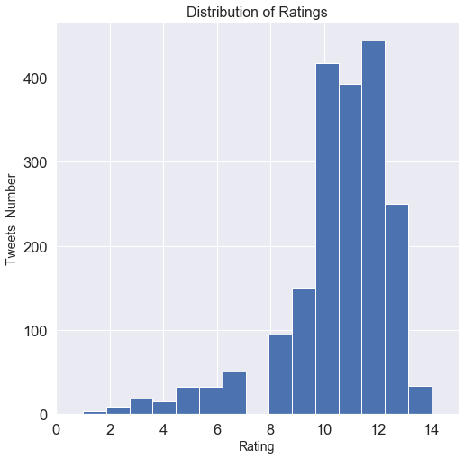

```python
we_rate_dogs['rating'].plot(kind = 'hist', bins = 15, figsize = (8, 8))

plt.xlim(0, 15)
plt.ylabel('Tweets  Number', fontsize = 14)
plt.xlabel('Rating', fontsize = 14)
plt.title('Distribution of Ratings', fontsize = 16);
```

#### Note:

The distribution of ratings is very skewed to the left.

From the plot above we see that most of ratings are between 10 and 14 inclusive.

```python
#let's see what percentage of tweets have ratings < 10

sum_rating_10up = sum(we_rate_dogs.rating >= 10)
prop_rating_10up = round(sum_rating_10up * 100 / we_rate_dogs.shape[0])
```

```python
print("Number of tweets with rating between 10 and 14: {}".format(sum_rating_10up))

print("Percentage of tweets with rating between 10 and 14: {}%".format(round(prop_rating_10up)))
```

```
Number of tweets with rating between 10 and 14: 1538
Percentage of tweets with rating between 10 and 14: 79%
```

```python
#what is the most favourite tweets?
most_fav = we_rate_dogs.sort_values(by = 'favorite_count', ascending = False)
most_fav.head()
```

|  | tweet_id | timestamp | rating | retweet_count | favorite_count | predicted_breed | confidence | dog_class | name | source | text |
| --- | --- | --- | --- | --- | --- | --- | --- | --- | --- | --- | --- |
| 756 | 744234799360020481 | 2016-06-18 18:26:18+00:00 | 13 | 79474 | 159253 | Labrador_retriever | 82 | doggo | None | Twitter for iPhone | Here's a doggo realizing you can stand in a po... |
| 301 | 822872901745569793 | 2017-01-21 18:26:02+00:00 | 13 | 44836 | 135797 | Lakeland_terrier | 19 | puppo | None | Twitter for iPhone | Here's a super supportive puppo participating ... |
| 390 | 807106840509214720 | 2016-12-09 06:17:20+00:00 | 13 | 57975 | 122992 | Chihuahua | 50 | none | Stephan | Twitter for iPhone | This is Stephan. He just wants to help. 13/10 ... |
| 107 | 866450705531457537 | 2017-05-22 00:28:40+00:00 | 13 | 33634 | 118436 | French_bulldog | 90 | pupper | Jamesy | Twitter for iPhone | This is Jamesy. He gives a kiss to every other... |
| 791 | 739238157791694849 | 2016-06-04 23:31:25+00:00 | 13 | 58917 | 117580 | Eskimo_dog | 50 | doggo | None | Twitter for iPhone | Here's a doggo blowing bubbles. It's downright... |

```python
#what is the most retwweted tweets?
most_retweet = we_rate_dogs.sort_values(by = 'retweet_count', ascending = False)
most_retweet.head()
```

|  | tweet_id | timestamp | rating | retweet_count | favorite_count | predicted_breed | confidence | dog_class | name | source | text |
| --- | --- | --- | --- | --- | --- | --- | --- | --- | --- | --- | --- |
| 756 | 744234799360020481 | 2016-06-18 18:26:18+00:00 | 13 | 79474 | 159253 | Labrador_retriever | 82 | doggo | None | Twitter for iPhone | Here's a doggo realizing you can stand in a po... |
| 791 | 739238157791694849 | 2016-06-04 23:31:25+00:00 | 13 | 58917 | 117580 | Eskimo_dog | 50 | doggo | None | Twitter for iPhone | Here's a doggo blowing bubbles. It's downright... |
| 390 | 807106840509214720 | 2016-12-09 06:17:20+00:00 | 13 | 57975 | 122992 | Chihuahua | 50 | none | Stephan | Twitter for iPhone | This is Stephan. He just wants to help. 13/10 ... |
| 301 | 822872901745569793 | 2017-01-21 18:26:02+00:00 | 13 | 44836 | 135797 | Lakeland_terrier | 19 | puppo | None | Twitter for iPhone | Here's a super supportive puppo participating ... |
| 58 | 879415818425184262 | 2017-06-26 19:07:24+00:00 | 13 | 41382 | 101018 | English_springer | 38 | none | Duddles | Twitter for iPhone | This is Duddles. He did an attempt. 13/10 some... |

#### Note:

The tweet with the highest favourite_count, it is also the most retweeted tweet.

```python
#How many tweets have favorite count <= retweet count?

sum(we_rate_dogs.favorite_count <= we_rate_dogs.retweet_count)
```

```
0
```

```python
#What is the most common breed?

#first let's figure how many breeds we have?

we_rate_dogs.predicted_breed.value_counts()
```

```
none                    302
golden_retriever        154
Labrador_retriever      101
Pembroke                 94
Chihuahua                90
                       ...
Irish_wolfhound           1
Scotch_terrier            1
Bouvier_des_Flandres      1
silky_terrier             1
EntleBucher               1
Name: predicted_breed, Length: 113, dtype: int64
```

```python
print('Number of distinct breeds:  {}'.format(len(we_rate_dogs.predicted_breed.unique())))
```

```
Number of distinct breeds:  113
```

```python
none_count = sum(we_rate_dogs.predicted_breed == 'none')
none_prop = none_count * 100 / we_rate_dogs.shape[0]

print('Number of tweets with no predicted breed:  {} ({}%)'.format(none_count, round(none_prop)))
```

```
Number of tweets with no predicted breed:  302 (16%)
```

```python
#What is the most common breed that is not None?

Top_breed = we_rate_dogs[we_rate_dogs.predicted_breed != 'none']

Top_breed.predicted_breed.value_counts().head()
```

```
golden_retriever      154
Labrador_retriever    101
Pembroke               94
Chihuahua              90
pug                    62
Name: predicted_breed, dtype: int64
```

```python
x = Top_breed.predicted_breed.value_counts().head(10)
```

[figure not shown]

```python
#let's plot top 10 breeds counts

plt.barh(x.index, x)
plt.xlabel('Tweets Number', fontsize = 14)
plt.gca().invert_yaxis()
plt.title('Top 10 Dog Breeds by Tweet Count', fontsize = 16);
```

#### Note:

The most common dog breed that is tweeted about, with almost 160 tweets, is the Golden Retriever.

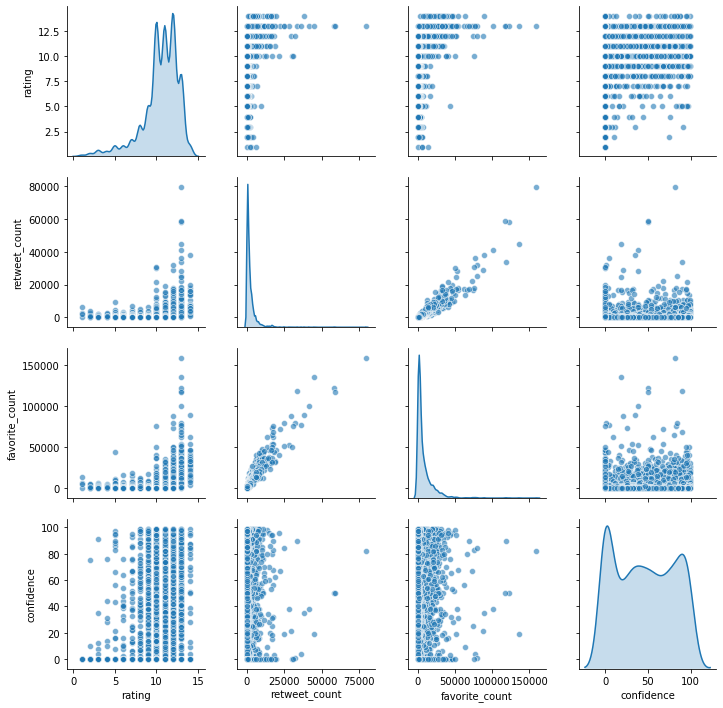

```python
#let's explore bivariant variables

sns.pairplot(we_rate_dogs,
             vars = ['rating', 'retweet_count', 'favorite_count', 'confidence'],
             diag_kind = 'kde', plot_kws = {'alpha': 0.6});
```

```python
#l'et's find out what is the most favourite dog breed?

fav_breed = we_rate_dogs[we_rate_dogs.predicted_breed != 'none']

fav_breed = fav_breed.groupby(['predicted_breed'])

fav_breed = fav_breed['favorite_count'].sum()

fav_breed = fav_breed.sort_values(ascending = False)

fav_breed.head()
```

```
predicted_breed
golden_retriever      1829368
Labrador_retriever    1131198
Pembroke               986286
Chihuahua              731131
French_bulldog         571680
Name: favorite_count, dtype: int32
```

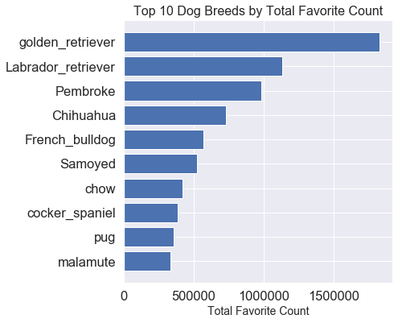

```python
#let's plot these results

x = fav_breed.head(10)

plt.barh(x.index, x)

plt.xlabel('Total Favorite Count', fontsize = 14)
plt.title('Top 10 Dog Breeds by Total Favorite Count', fontsize = 16)
plt.gca().invert_yaxis();
```

#### Note:

It looks very similar to the barplot ealier of top 10 dog breeds ranked by tweet, and in fact the top 4 dog breeds are the same

```python
#let's start multivariant analysis
#let's explore some change over time

from matplotlib import cm
```

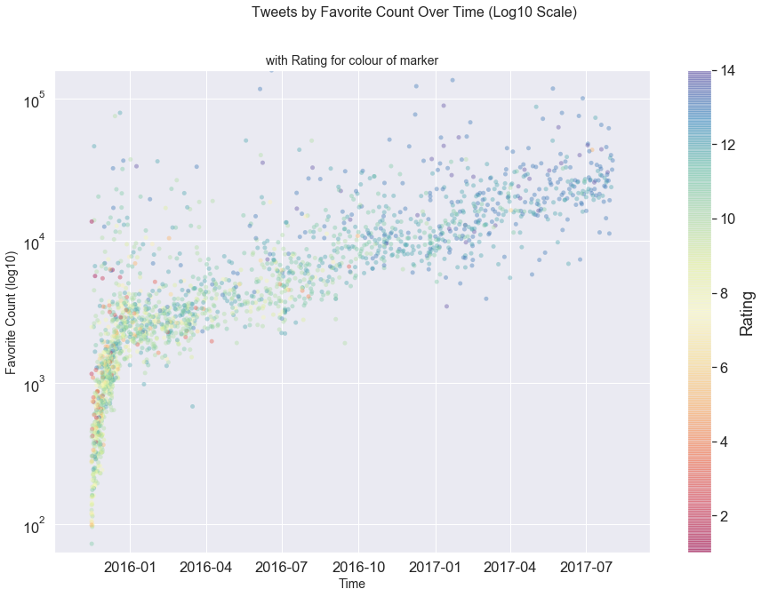

```python
#Favourite counts over time, colored with dog rating.

cmap = cm.get_cmap('Spectral')

plt.figure(figsize = (15, 10))

plt.yscale('log')
plt.ylim(we_rate_dogs['favorite_count'].min(),
         we_rate_dogs['favorite_count'].max())

colours = we_rate_dogs['rating']

markers = 25

plt.scatter(we_rate_dogs['timestamp'], we_rate_dogs['favorite_count'],
            c = colours, s = markers, cmap = cmap, edgecolor = 'None', alpha = 0.4)

# title and labels
plt.suptitle('Tweets by Favorite Count Over Time (Log10 Scale)', fontsize = 16)
plt.title('with Rating for colour of marker', fontsize = 14)
plt.xlabel('Time', fontsize = 14)
plt.ylabel('Favorite Count (log10)', fontsize = 14)

cbar = plt.colorbar()
cbar.set_label('Rating');
```

#### Note:

Clearly, the more recent tweets (on the right side) are rated consistently higher (blue and green) than much older tweets (yellow and green).

The slope of the line is also increasing at a steady rate from around january 2016, reflecting the increase in tweets being favorited. This clearly shows that the Twitter account followers were active, and possibly growing, during the timeframe represented in the archive.

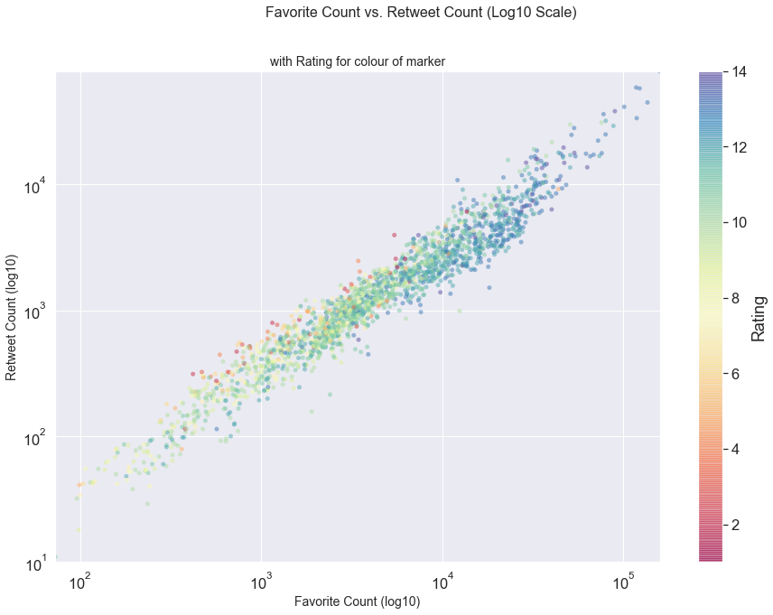

```python
#let's explore the relationship between favourite and retweet counts colored with dog rating

plt.figure(figsize = (15, 10))

plt.xscale('log')
plt.yscale('log')
plt.xlim(we_rate_dogs['favorite_count'].min(),
         we_rate_dogs['favorite_count'].max())

plt.ylim(10,
         we_rate_dogs['retweet_count'].max() )

colours = we_rate_dogs['rating']
markers = 25

plt.scatter(we_rate_dogs['favorite_count'], we_rate_dogs['retweet_count'],
            c = colours, s = markers, cmap = cmap, edgecolor = 'None', alpha = 0.5)

# title and labels
plt.suptitle('Favorite Count vs. Retweet Count (Log10 Scale)', fontsize = 16)
plt.title('with Rating for colour of marker', fontsize = 14)
plt.xlabel('Favorite Count (log10)', fontsize = 14)
plt.ylabel('Retweet Count (log10)', fontsize = 14)

# colour bar
cbar = plt.colorbar()
cbar.set_label('Rating');
```

#### Note:

This plot is showing that there is a strong positive correlation between retweet counts and favorite counts. It does make sense though, as if you 'like' a tweet (favourite it), you are more likely to retweet it as well.

The tightly packed points follow a distinct linear trend with a positive slope, so as favorite count increases so does the retweet count.

Also evident, tweets with high favorite counts and high retweet counts also have higher ratings, as shown by the concentration of blue points.

### Conclusion

This project aims to perform the Data Wrangling and the Exploratory Data Analysis over the WeRateDogs Twitter account archive.

The Data Gathering process included three different tasks:

- The first one download file from URL and later loading to the Jupyter Notebook, which requires a manual step
- The second was to download a file programmatically
- The third was to gather data from the Twitter API.

Based on the data gathered, I have assessed the most evident issues and documented it to create a record of modifications.

Later, in Data Cleaning process I have fixed all identified issues to complete, and I have also merged separated data frame into one and added some missing values.

The final data frame was stored as twitter_archive_master.csv.

In the Data Analysis and Visualization, which I have interpreted as Exploratory Analysis and tried to find some insights and realtionships between the variables.